# Coding Assignment 3

Team 4

Due: 2024-12-07 23:59

A Florida health insurance company wants to predict annual claims for individual clients. The company pulls a random sample of 100 customers. The owner wishes to charge an actuarially fair premium to ensure a normal rate of return. The owner collects all of their current customer’s health care expenses from the last year and compares them with what is known about each customer’s plan.

The data on the 100 customers in the sample is as follows:

- Charges: Total medical expenses for a particular insurance plan (in dollars)
- Age: Age of the primary beneficiary
- BMI: Primary beneficiary’s body mass index (kg/m2)
- Female: Primary beneficiary’s birth sex (0 = Male, 1 = Female)
- Children: Number of children covered by health insurance plan (includes other dependents as well)
- Smoker: Indicator if primary beneficiary is a smoker (0 = non-smoker, 1 = smoker)
- Cities: Dummy variables for each city with the default being Sanford

Answer the following questions using complete sentences and attach all output, plots, etc. within this report.

```r
# Bring in the dataset here.
#insurance_data <- read.csv("~/Documents/GitHub/ECO6416_Group04/Insurance_Data_Group4.csv"

insurance <- read.csv("~/Documents/GitHub/ECO6416_Group04/Insurance_Data_Group4.csv")
```

## Question 1

Randomly select 30 observations from the sample and exclude from all modeling. Provide the summary statistics (min, max, std, mean, median) of the quantitative variables for the 70 observations.

```r
#
set.seed(123)
index <- sample(seq_len(nrow(insurance)), size = 30)
train <- insurance[-index,]
test <- insurance[index,]

train %>%
  tbl_summary(statistic = list(all_continuous() ~ c("{mean} ({sd})",
                                                    "{median} ({p25}, {p75})",
                                                    "{min}, {max}"),
                              all_categorical() ~ "{n} / {N} ({p}%)"),
              type = all_continuous() ~ "continuous2"
  )
```

| **Characteristic** | **N = 70**<sup>1</sup> |
| --- | --- |
| Charges |  |
| Mean (SD) | 12,410 (11,508) |
| Median (Q1, Q3) | 9,162 (4,890, 13,430) |
| Min, Max | 1,636, 47,270 |
| Age |  |
| Mean (SD) | 39 (13) |
| Median (Q1, Q3) | 38 (28, 51) |
| Min, Max | 18, 64 |
| BMI |  |
| Mean (SD) | 32 (6) |
| Median (Q1, Q3) | 32 (28, 36) |
| Min, Max | 17, 44 |
| Female | 35 / 70 (50%) |
| Children |  |
| 0 | 28 / 70 (40%) |
| 1 | 18 / 70 (26%) |
| 2 | 14 / 70 (20%) |
| 3 | 8 / 70 (11%) |
| 4 | 1 / 70 (1.4%) |
| 5 | 1 / 70 (1.4%) |
| Smoker | 13 / 70 (19%) |
| WinterSprings | 22 / 70 (31%) |
| WinterPark | 18 / 70 (26%) |
| Oviedo | 13 / 70 (19%) |

<sup>1</sup> n / N (%)

## Question 2

Provide the correlation between all quantitative variables

```r
included_data <- train %>% select(Charges, Age, BMI, Children)
cor(included_data)
```

```
##             Charges       Age        BMI   Children
## Charges  1.00000000 0.3280217 0.09857974 0.09822110
## Age      0.32802170 1.0000000 0.11903844 0.11346529
## BMI      0.09857974 0.1190384 1.00000000 0.03964289
## Children 0.09822110 0.1134653 0.03964289 1.00000000
```

Charges and Age have the strongest correlation out of all the variables. All of the rest of the variables (Charges & BMI, Charges & Children, Age & BMI, Age & Children, and BMI & Children) have weak positive correlation.

## Question 3

Run a regression that includes all independent variables in the data table. Does the model above violate any of the Gauss-Markov assumptions? If so, what are they and what is the solution for correcting?

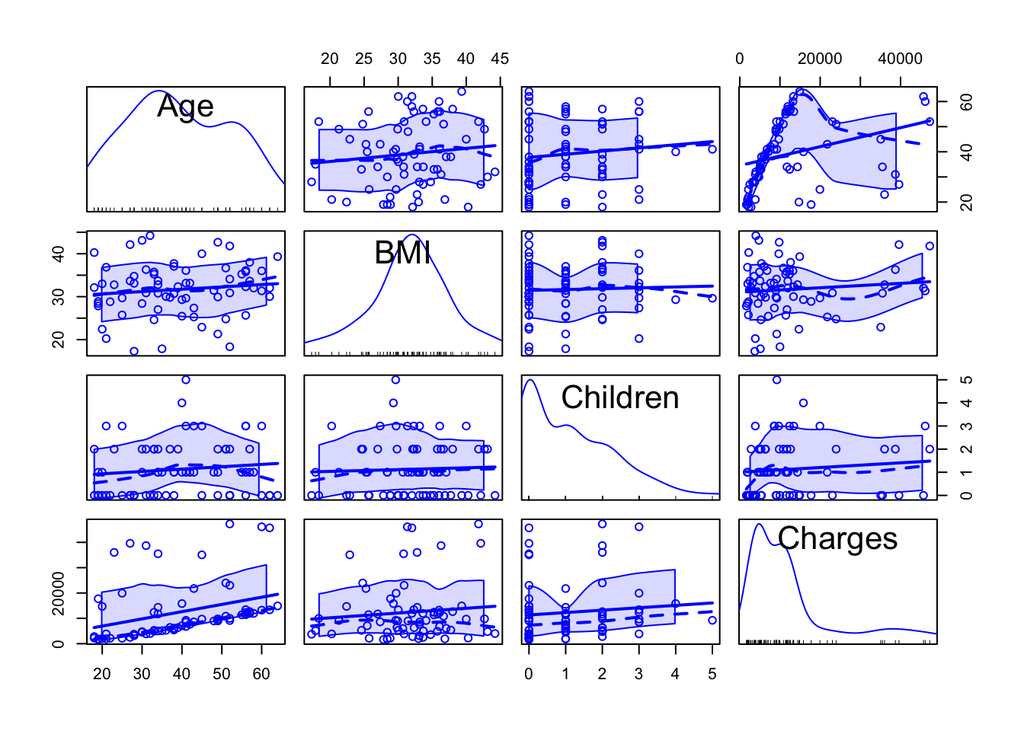

```r
model <- lm(Charges ~ Age + BMI + Children + Female + Smoker + WinterSprings + WinterPark + Oviedo, data = train)
sum<-summary(model)
scatterplotMatrix(train%>%select(Age, BMI, Children, Charges))
```

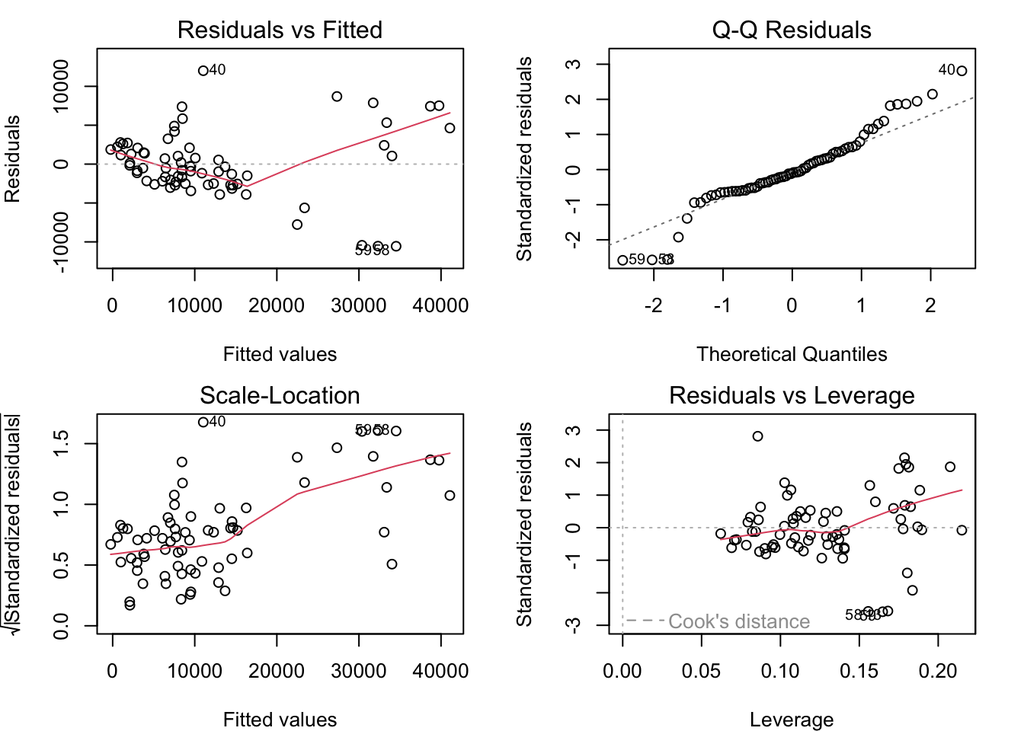

```r
par(mfrow=c(2,2), mar=c(4,4,2,2))
plot(model)
```

```r
library(lmtest)
dwtest(model)
```

```
##
##  Durbin-Watson test
##
## data:  model
## DW = 1.3075, p-value = 0.001694
## alternative hypothesis: true autocorrelation is greater than 0
```

## Question 4

Implement the solutions from question 3, such as data transformation, along with any other changes you wish. Use the sample data and run a new regression. How have the fit measures changed? How have the signs and significance of the coefficients changed?

```r
# Log Charges and Charges Squared
train$LogCharges <- log(train$Charges)
train$ChargesSquared <- train$Charges^2

# Log Age and Age Squared
train$LogAge <- log(train$Age)
train$AgeSquared <- train$Age^2

# Log Smoker and Smoker Squares
train$lnSmoker <- log(train$Smoker)
train$SmokerSquared <- train$Smoker^2

# Log BMI and BMI Squared
train$LogBMI <- log(train$BMI)
train$BMISquared <- train$BMI^2

# Interaction: Children and Age
model_1 <- lm(LogCharges ~LogAge + Children, data = train)
summary(model_1)
```

```
##
## Call:
## lm(formula = LogCharges ~ LogAge + Children, data = train)
##
## Residuals:
##     Min      1Q  Median      3Q     Max
## -0.8104 -0.4099 -0.2864  0.1768  2.0120
##
## Coefficients:
##             Estimate Std. Error t value Pr(>|t|)
## (Intercept)  4.42138    0.87123   5.075 3.30e-06 ***
## LogAge       1.26023    0.24260   5.195 2.09e-06 ***
## Children     0.08646    0.07410   1.167    0.247
## ---
## Signif. codes:  0 '***' 0.001 '**' 0.01 '*' 0.05 '.' 0.1 ' ' 1
##
## Residual standard error: 0.7253 on 67 degrees of freedom
## Multiple R-squared:  0.3144, Adjusted R-squared:  0.2939
## F-statistic: 15.36 on 2 and 67 DF,  p-value: 3.222e-06
```

```r
# Interaction: Smoker and Female
model_2 <- lm(LogCharges ~ SmokerSquared + Female, data = train)
summary(model_2)
```

```
##
## Call:
## lm(formula = LogCharges ~ SmokerSquared + Female, data = train)
##
## Residuals:
##     Min      1Q  Median      3Q     Max
## -1.3435 -0.3981  0.1310  0.4561  1.2389
##
## Coefficients:
##               Estimate Std. Error t value Pr(>|t|)
## (Intercept)    8.74332    0.11690  74.794  < 2e-16 ***
## SmokerSquared  1.55813    0.19527   7.979 2.62e-11 ***
## Female         0.06303    0.15188   0.415    0.679
## ---
## Signif. codes:  0 '***' 0.001 '**' 0.01 '*' 0.05 '.' 0.1 ' ' 1
##
## Residual standard error: 0.6245 on 67 degrees of freedom
## Multiple R-squared:  0.4917, Adjusted R-squared:  0.4765
## F-statistic:  32.4 on 2 and 67 DF,  p-value: 1.43e-10
```

```r
# Interaction: BMI and Oviedo
model_3 <- lm(LogCharges ~train$LogBMI + Oviedo, data = train)
summary(model_3)
```

```
##
## Call:
## lm(formula = LogCharges ~ train$LogBMI + Oviedo, data = train)
##
## Residuals:
##      Min       1Q   Median       3Q      Max
## -1.72491 -0.57096  0.07982  0.42706  1.71932
##
## Coefficients:
##              Estimate Std. Error t value Pr(>|t|)
## (Intercept)    8.0302     1.7546   4.577  2.1e-05 ***
## train$LogBMI   0.2873     0.5098   0.563    0.575
## Oviedo         0.2523     0.2669   0.945    0.348
## ---
## Signif. codes:  0 '***' 0.001 '**' 0.01 '*' 0.05 '.' 0.1 ' ' 1
##
## Residual standard error: 0.868 on 67 degrees of freedom
## Multiple R-squared:  0.01811,    Adjusted R-squared:  -0.0112
## F-statistic: 0.6177 on 2 and 67 DF,  p-value: 0.5422
```

```r
# Regression without Children, Female
model_4 <- lm(Charges ~ Age + BMI + Smoker + WinterSprings + WinterPark + Oviedo, data = insurance)
summary(model_4)
```

```
##
## Call:
## lm(formula = Charges ~ Age + BMI + Smoker + WinterSprings + WinterPark +
##     Oviedo, data = insurance)
##
## Residuals:
##      Min       1Q   Median       3Q      Max
## -10338.1  -2274.3   -403.7   1787.6  11705.2
##
## Coefficients:
##                Estimate Std. Error t value Pr(>|t|)
## (Intercept)   -12759.86    2803.59  -4.551 1.61e-05 ***
## Age              285.01      34.93   8.160 1.57e-12 ***
## BMI              238.92      82.08   2.911  0.00451 **
## Smoker         24141.00    1183.24  20.403  < 2e-16 ***
## WinterSprings   2435.16    1251.91   1.945  0.05478 .
## WinterPark      2190.04    1323.01   1.655  0.10123
## Oviedo          2278.63    1311.64   1.737  0.08566 .
## ---
## Signif. codes:  0 '***' 0.001 '**' 0.01 '*' 0.05 '.' 0.1 ' ' 1
##
## Residual standard error: 4410 on 93 degrees of freedom
## Multiple R-squared:  0.8429, Adjusted R-squared:  0.8328
## F-statistic: 83.16 on 6 and 93 DF,  p-value: < 2.2e-16
```

```r
# Regression without Age, Smoker
model_5 <- lm(Charges ~ BMI + Children + Female + WinterSprings + WinterPark + Oviedo, data = insurance)
summary(model_5)
```

```
##
## Call:
## lm(formula = Charges ~ BMI + Children + Female + WinterSprings +
##     WinterPark + Oviedo, data = insurance)
##
## Residuals:
##    Min     1Q Median     3Q    Max
## -13197  -7384  -3534   3529  32265
##
## Coefficients:
##               Estimate Std. Error t value Pr(>|t|)
## (Intercept)     4814.7     6174.5   0.780   0.4375
## BMI              279.4      199.2   1.403   0.1641
## Children        1007.1      964.9   1.044   0.2993
## Female         -4018.3     2204.6  -1.823   0.0716 .
## WinterSprings   -315.2     3034.4  -0.104   0.9175
## WinterPark     -1350.5     3176.1  -0.425   0.6717
## Oviedo         -1895.5     3188.1  -0.595   0.5536
## ---
## Signif. codes:  0 '***' 0.001 '**' 0.01 '*' 0.05 '.' 0.1 ' ' 1
##
## Residual standard error: 10710 on 93 degrees of freedom
## Multiple R-squared:  0.07253,    Adjusted R-squared:  0.0127
## F-statistic: 1.212 on 6 and 93 DF,  p-value: 0.3071
```

```r
#
```

## Question 5

Use the 30 withheld observations and calculate the performance measures for your best two models. Which is the better model? (remember that “better” depends on whether your outlook is short or long run)

```r
test$LogCharges <- log(test$Charges)
test$LogAge <- log(test$Age)
test$SmokerSquared <- test$Smoker^2

test$model_1_pred <- predict(model_1, newdata= test) %>% exp ()
test$model_2_pred <- predict(model_2, newdata= test) %>% exp ()

test$error_1 <- test$model_1_pred - test$Charges
test$error_2 <- test$model_2_pred - test$Charges

library(Metrics)
mae <- function(error_vector){error_vector %>%  abs() %>%  mean()}

rmse <- function(error_vector){
   error_vector^2 %>%  mean() %>% sqrt()}

mape <- function(error_vector, actual_vector){
  (error_vector/actual_vector) %>%
    abs() %>%
    mean()
}

bias <- mean(test$error_1)
print("Mean for Model 1")
```

```
## [1] "Mean for Model 1"
```

```r
print(bias)
```

```
## [1] -282.1988
```

```r
mae <- mae(test$error_1)
print("MAE for Model 1")
```

```
## [1] "MAE for Model 1"
```

```r
print(mae)
```

```
## [1] 4774.571
```

```r
mape <- mape(test$error_1, test$Charges)
print("MAPE for Model 1")
```

```
## [1] "MAPE for Model 1"
```

```r
print(mape)
```

```
## [1] 0.5287979
```

```r
rmse <- rmse(test$error_1)
print("RMSE for Model 1")
```

```
## [1] "RMSE for Model 1"
```

```r
print(rmse)
```

```
## [1] 7471.25
```

```r
bias <- mean(test$error_2)
print("Mean for Model 2")
```

```
## [1] "Mean for Model 2"
```

```r
print(bias)
```

```
## [1] -1103.31
```

```r
mae <- mae(test$Charges, test$model_2_pred)
print("MAE for Model 2")
```

```
## [1] "MAE for Model 2"
```

```r
print(mae)
```

```
## [1] 4189.401
```

```r
mape <- mape(test$error_2, test$Charges)
print("MAPE for Model 2")
```

```
## [1] "MAPE for Model 2"
```

```r
print(mape)
```

```
## [1] 5.530149
```

```r
rmse <- rmse(test$Charges, test$model_2_pred)
print("RMSE for Model 2")
```

```
## [1] "RMSE for Model 2"
```

```r
print(rmse)
```

```
## [1] 5307.092
```

## Question 6

Provide interpretations of the coefficients, do the signs make sense? Perform marginal change analysis (thing 2) on the independent variables.

```r
coefficients <- coef(model_1)
print(coefficients)
```

```
## (Intercept)      LogAge    Children
##  4.42138334  1.26022586  0.08646065
```

```r
beta_Children <- coefficients["Children"]
marginal_changeChildren <- beta_Children
beta_Age <- coefficients["LogAge"]
marginal_changeAge <- beta_Age
print(paste("Marginal Change for Log Age", marginal_changeAge))
```

```
## [1] "Marginal Change for Log Age 1.26022586186334"
```

```r
print(paste("Marginal Change for Children", marginal_changeChildren))
```

```
## [1] "Marginal Change for Children 0.0864606514402538"
```

LogAge shows that for every 1% increase, the log charges will increase by 1.26% units. There is a significant relationship between age and charges in the log transformation. The sign on this makes sense because as age increases, healthcare costs will typically increase because they are at higher risk of health-related problems.

## Question 7

An eager insurance representative comes back with five potential clients. Using the better of the two models selected above, provide the prediction intervals for the five potential clients using the information provided by the insurance rep.

| Customer | Age | BMI | Female | Children | Smoker | City |
| --- | --- | --- | --- | --- | --- | --- |
| 1 | 60 | 22 | 1 | 0 | 0 | Oviedo |
| 2 | 40 | 30 | 0 | 1 | 0 | Sanford |
| 3 | 25 | 25 | 0 | 0 | 1 | Winter Park |
| 4 | 33 | 35 | 1 | 2 | 0 | Winter Springs |
| 5 | 45 | 27 | 1 | 3 | 0 | Oviedo |

```r
new_clients <- data.frame(
  Age = c(60, 40, 25, 33, 45),
  BMI = c(22, 30, 25, 35, 27),
  Female = c(1, 0, 0, 1, 1),
  Children = c(0, 1, 0, 2, 3),
  Smoker = c(0, 0, 1, 0, 0),
  City = c("Oviedo", "Sanford", "Winter Park", "Winter Springs", "Oviedo")
)

new_clients$LogAge <- log(new_clients$Age)
new_clients$SmokerSquared <- new_clients$Smoker^2
new_clients$LogCharges
```

```r
new_clients$model_2_pred <- predict(model_2, newdata = new_clients)

new_clients$lower_PI <- new_clients$model_2_pred - 1.96 * sd(new_clients$model_2_pred)
new_clients$upper_PI <- new_clients$model_2_pred + 1.96 * sd(new_clients$model_2_pred)

print(new_clients)
```

```
##   Age BMI Female Children Smoker           City   LogAge SmokerSquared
## 1  60  22      1        0      0         Oviedo 4.094345             0
## 2  40  30      0        1      0        Sanford 3.688879             0
## 3  25  25      0        0      1    Winter Park 3.218876             1
## 4  33  35      1        2      0 Winter Springs 3.496508             0
## 5  45  27      1        3      0         Oviedo 3.806662             0
##   model_2_pred lower_PI upper_PI
## 1     8.806359 7.480954 10.13176
## 2     8.743325 7.417919 10.06873
## 3    10.301459 8.976053 11.62686
## 4     8.806359 7.480954 10.13176
## 5     8.806359 7.480954 10.13176
```

## Question 8

The owner notices that some of the predictions are wider than others, explain why.

## Question 9

Are there any prediction problems that occur with the five potential clients? If so, explain.